# Gender Wage Gap Analysis (2015–2023)

## Closing the Wage Gap: A DEI-Driven Data Dashboard for Employer Brand & Equity Campaigns

Author: Nishtha Sood

### 📌 Abstract

This project investigates gender-based wage disparities across education levels and occupations using U.S. Census and the Bureau of Labor Statistics.

The dashboard is built to help HR, DEI, and employer branding teams identify pay gaps and prioritize areas for intervention. The goal is to inform equitable hiring, compensation audits, and diversity policies.

### 📈 Tools & Techniques Used

- **Python**: Data cleaning, aggregation, and modeling
- **Pandas & Seaborn**: Visualizations (line charts, heatmaps, bar plots)
- **Linear Regression**: Modeled wage gap as a function of education and time
- **Data Sources**: U.S. Census (ACS), Bureau of Labor Statistics (BLS)

### 🎯 Business Applications

- **HR & Compensation Strategy**: Prioritize wage audits by education level or job category
- **DEI Marketing**: Use insights to drive data-backed recruitment messaging for women in STEM, finance, or executive leadership
- **Employer Brand Content**: Highlight progress in narrowing gaps post-COVID in PR or campaign materials

```python
# 1.1 Import Libraries
import pandas as pd
import numpy as np
import os
import seaborn as sns
import matplotlib.pyplot as plt
from sklearn.linear_model import LinearRegression
from sklearn.preprocessing import LabelEncoder

sns.set(style="whitegrid")
plt.rcParams["figure.figsize"] = (12, 6)
```

### Methodology

#### Data Sources:

- **ACS Wage by Education**: U.S. Census Bureau, 2015–2023
- **Occupation-Level Wages**: Bureau of Labor Statistics (BLS), 2024
- **Work Flexibility**: Selected CPS tables

#### Analytical Methods:

- Descriptive statistics
- Cross-sectional comparisons
- Linear regression modeling

```python
# 2.1 Define file paths and years

folder = "/Users/nishthasood/Desktop/gender wage gap"
years = [2015, 2016, 2017, 2018, 2019, 2021, 2022, 2023]
edu_levels = [
    "Less than high school graduate",
    "High school graduate (includes equivalency)",
    "Some college or associate's degree",
    "Bachelor's degree",
    "Graduate or professional degree"
]
```

```python
## Load Education Data

def load_acs_data(years, edu_levels, folder):
    wage_data = []

    for year in years:
        file_path = os.path.join(folder, f"ACSDT1Y{year}.B20004-Data.csv")
        try:
            df = pd.read_csv(file_path, skiprows=1)

            # Try both formats
            for level in edu_levels:
                formats = [
                    f"Estimate!!Total!!Male!!{level}",
                    f"Estimate!!Total:!!Male:!!{level}"
                ]
                male_col = next((col for col in formats if col in df.columns), None)

                formats = [
                    f"Estimate!!Total!!Female!!{level}",
                    f"Estimate!!Total:!!Female:!!{level}"
                ]
                female_col = next((col for col in formats if col in df.columns), None)

                if male_col and female_col:
                    male = df[male_col].iloc[0]
                    female = df[female_col].iloc[0]
                    if male and female and male != 0:
                        wage_data.append({
                            "Year": year,
                            "Education_Level": level,
                            "Male_Earnings": male,
                            "Female_Earnings": female,
                            "Wage_Gap_%": ((male - female) / male) * 100
                        })
        except Exception as e:
            print(f"Failed to load {file_path}: {e}")

    return pd.DataFrame(wage_data)
```

```python
edu_df = load_acs_data(years, edu_levels, folder)
edu_df["Year"].unique()
```

```
array([2015, 2016, 2017, 2018, 2019, 2021, 2022, 2023])
```

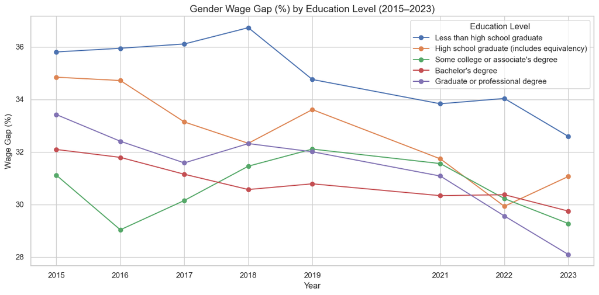

```python
## Visualization 1 — Wage Gap by Education Over Time

plt.figure(figsize=(12, 6))

# Line per education level
for level in edu_df["Education_Level"].unique():
    subset = edu_df[edu_df["Education_Level"] == level]
    plt.plot(subset["Year"], subset["Wage_Gap_%"], marker='o', label=level)

plt.title("Gender Wage Gap (%) by Education Level (2015–2023)", fontsize=14)
plt.xlabel("Year")
plt.ylabel("Wage Gap (%)")
plt.xticks(sorted(edu_df["Year"].unique()))
plt.legend(title="Education Level")
plt.grid(True)
plt.tight_layout()
plt.show()
```

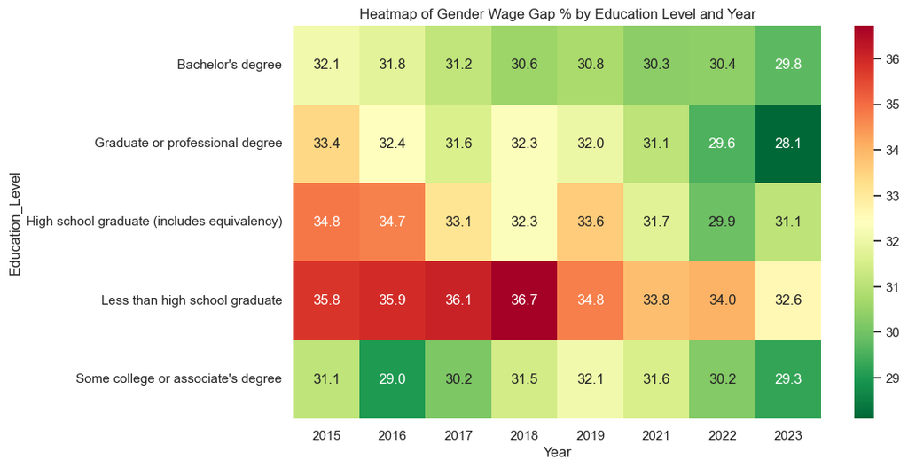

```python
## Heatmap of Gender Wage Gaps by Education Level and Year

edu_df = load_acs_data(years, edu_levels, folder)

heatmap_data = edu_df.pivot(index="Education_Level", columns="Year", values="Wage_Gap_%")
plt.figure(figsize=(10, 6))
sns.heatmap(heatmap_data, annot=True, cmap="RdYlGn_r", fmt=".1f")
plt.title("Heatmap of Gender Wage Gap % by Education Level and Year")
plt.show()
```

#### Key Observations:

> This visualization helps HR and DEI teams quickly identify which education segments and years require deeper wage audit or communication strategy adjustments.

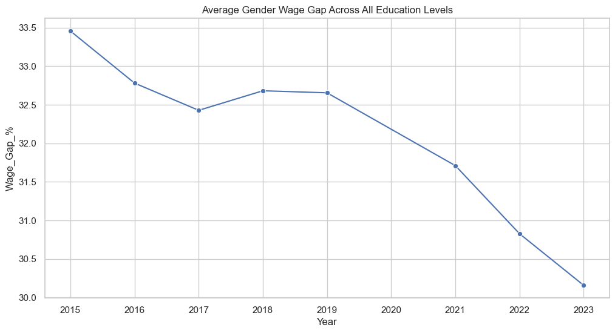

```python
## Visualization 2 — Avg Wage Gap Trend

avg_gap = edu_df.groupby("Year")["Wage_Gap_%"].mean().reset_index()
sns.lineplot(data=avg_gap, x="Year", y="Wage_Gap_%", marker='o')
plt.title("Average Gender Wage Gap Across All Education Levels")
plt.show()
```

**Observation**: The average gap shows modest improvement over time, dropping post-2019.

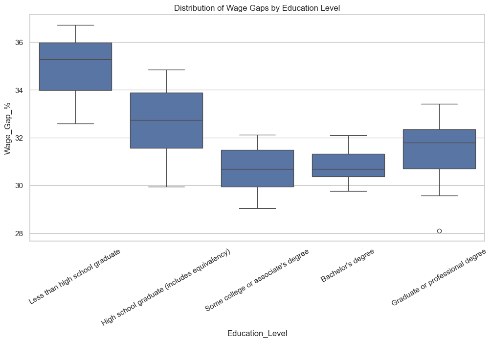

```python
# Boxplot

sns.boxplot(data=edu_df, x="Education_Level", y="Wage_Gap_%")
plt.title("Distribution of Wage Gaps by Education Level")
plt.xticks(rotation=30)
plt.show()
```

```python
# Load occupation wage gap table (cleaned version)
occ_df = pd.read_excel(os.path.join(folder, "cpsa2024.xlsx"), sheet_name="cpsaat39", skiprows=4)

# Clean the table
occ_df = occ_df.dropna(subset=["Unnamed: 0", "Unnamed: 4", "Unnamed: 6"])
occ_df = occ_df.rename(columns={
    "Unnamed: 0": "Occupation",
    "Unnamed: 4": "Male_Median_Weekly_Wage",
    "Unnamed: 6": "Female_Median_Weekly_Wage"
})
occ_df["Male_Median_Weekly_Wage"] = pd.to_numeric(occ_df["Male_Median_Weekly_Wage"], errors='coerce')
occ_df["Female_Median_Weekly_Wage"] = pd.to_numeric(occ_df["Female_Median_Weekly_Wage"], errors='coerce')
occ_df = occ_df.dropna(subset=["Male_Median_Weekly_Wage", "Female_Median_Weekly_Wage"])
occ_df["Wage_Gap_%"] = ((occ_df["Male_Median_Weekly_Wage"] - occ_df["Female_Median_Weekly_Wage"]) / occ_df["Male_Median_Weekly_Wage"]) * 100
occ_df = occ_df.sort_values(by="Wage_Gap_%", ascending=False)
```

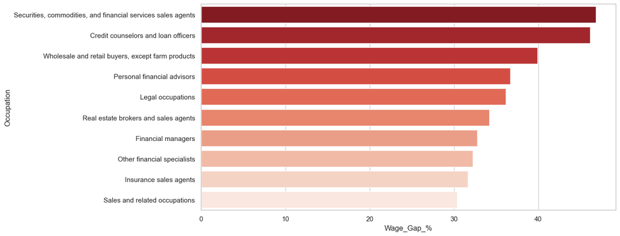

```python
# Top 10 occupation wage gaps
top10 = occ_df.head(10)

# Bar plot
plt.figure(figsize=(12, 6))
sns.barplot(
    data=top10,
    x="Wage_Gap_%",
    y="Occupation",
    hue="Occupation",
    dodge=False,
    palette="Reds_r",
    legend=False
)
```

### 🔻 Top 10 Occupations with the Largest Gender Wage Gaps

This chart highlights occupations with the most severe wage disparities between men and women. Highest gaps appear in finance, legal, and high-skill advisory roles. These sectors often have subjective performance evaluation systems, discretionary bonus structures, and a lack of wage transparency — all of which can exacerbate gender-based earnings inequality.

The findings underscore the importance of structured pay bands, transparent promotion criteria, and equitable access to high-paying client-facing roles in these industries.

These roles are strong targets for wage audit campaigns and internal equity reviews. They also represent high-stakes verticals for women-focused upskilling or employer branding campaigns.

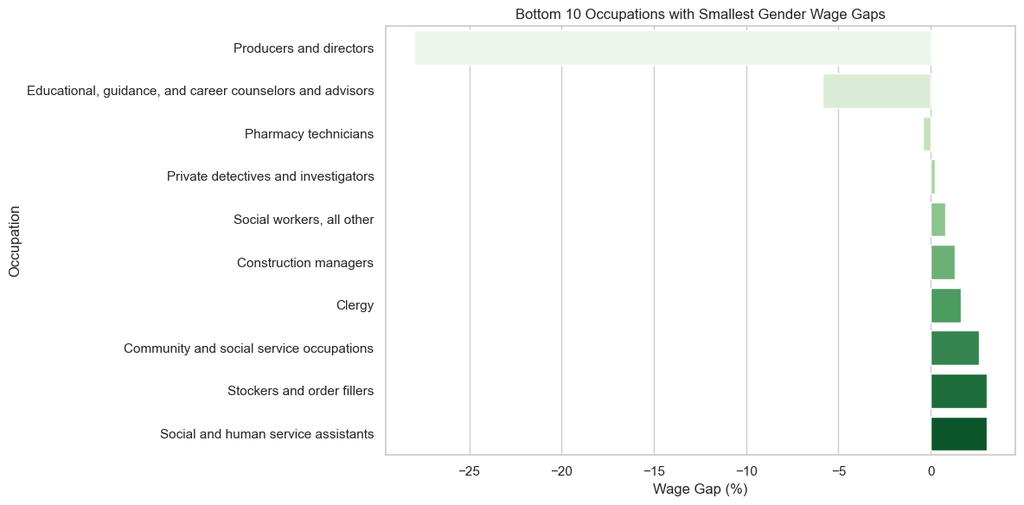

```python
# Bottom 10 occupation wage gaps
bottom10 = occ_df.sort_values(by="Wage_Gap_%", ascending=True).head(10)

# Bar plot
plt.figure(figsize=(12, 6))
sns.barplot(
    data=bottom10,
    x="Wage_Gap_%",
    y="Occupation",
    hue="Occupation",
    dodge=False,
    palette="Greens",
    legend=False
)

plt.title("Bottom 10 Occupations with Smallest Gender Wage Gaps")
plt.xlabel("Wage Gap (%)")
plt.ylabel("Occupation")
plt.tight_layout()
plt.show()
```

### 🟢 Bottom 10 Occupations with the Smallest Gender Wage Gaps

While these occupations may offer more equitable pay, they also tend to fall on the lower end of the earnings spectrum. Thus, achieving pay equity in high-income industries remains essential for narrowing the overall gender wage gap.

These roles may require less urgent wage intervention but offer storytelling opportunities around gender equity in recruitment materials.

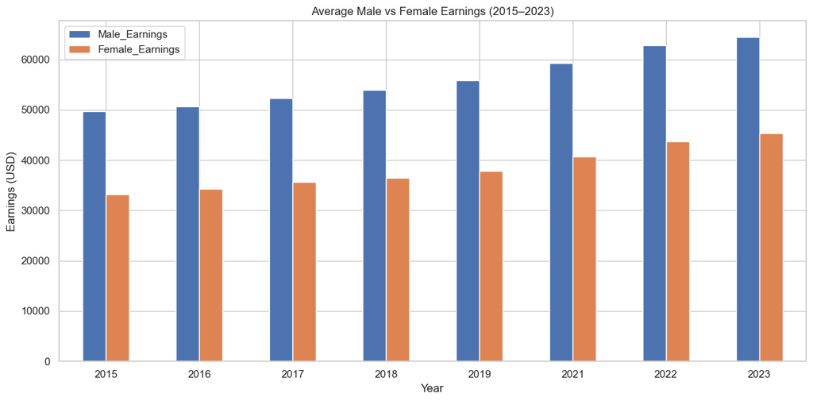

```python
# Average earnings per year
avg_earnings = edu_df.groupby("Year")[["Male_Earnings", "Female_Earnings"]].mean().reset_index()

avg_earnings.plot(
    x="Year",
    y=["Male_Earnings", "Female_Earnings"],
    kind="bar",
    title="Average Male vs Female Earnings (2015–2023)",
    figsize=(12, 6)
)
plt.ylabel("Earnings (USD)")
plt.xticks(rotation=0)
plt.tight_layout()
plt.show()
```

```python
from sklearn.linear_model import LinearRegression
from sklearn.preprocessing import LabelEncoder
import numpy as np

# Encode education level to numeric
edu_df_reg = edu_df.copy()
edu_df_reg["Edu_Code"] = LabelEncoder().fit_transform(edu_df_reg["Education_Level"])

# Define X and y
X = edu_df_reg[["Edu_Code", "Year"]]
y = edu_df_reg["Wage_Gap_%"]

# Build model
model = LinearRegression()
model.fit(X, y)

# Output coefficients
intercept = model.intercept_
coeffs = model.coef_

print(f"Intercept: {intercept:.3f}")
print(f"Coef (Education Level): {coeffs[0]:.3f}")
print(f"Coef (Year): {coeffs[1]:.3f}")
```

```
Intercept: 754.443
Coef (Education Level): 0.318
Coef (Year): -0.358
```

### Average Male vs Female Earnings Over Time

While the gender wage gap % tells us the proportional disparity, this chart shows actual earnings. Male earnings consistently outpace female earnings, though both have increased modestly over time. Notably, the absolute gap has **not narrowed significantly**, reinforcing the persistence of pay inequity despite educational gains and social progress.

### 📉 Insight from Regression

  Year Coefficient = -0.358: Wage gaps decrease slowly over time (~0.36% per year).

### 🔍 Key Takeaways & Recommendations

#### ✅ Recommendations:

- Enforce wage transparency laws in private sectors.
- Encourage salary audits and equitable promotion structures.
- Normalize flexible work policies tied to pay equity metrics.

> Addressing the gender wage gap requires systemic change — not just individual education or career choices.